# 家庭外籍看護工——勞動待遇面面觀

勞動部移工管理及運用調查｜113年6月

分析報告

2026-05-03

# 前言

> 本報告聚焦於**家庭外籍看護工的勞動待遇**——薪資、工時、休假、保險、 薪資透明度等面向。我們特別標記了數據中**看似反常**的發現， 這些反常之處往往是深入研究最值得挖掘的地方。

> 資料來源：勞動部「移工管理及運用調查」113 年家庭面問卷（N = 4,016）

```r
library(tidyverse)
library(scales)
library(patchwork)
library(broom)
library(knitr)
library(RColorBrewer)
library(ggplot2)

# 全域視覺風格
theme_set(
  theme_minimal(base_family = "Microsoft JhengHei", base_size = 13) +
    theme(
      plot.title    = element_text(face = "bold", size = 16),
      plot.subtitle = element_text(color = "grey40", size = 12),
      plot.caption  = element_text(color = "grey60", size = 9),
      legend.position = "bottom",
      panel.grid.minor = element_blank()
    )
)

# 色票：全報告統一用三色系（配合「分類最多三種」原則）
pal3  <- c("#3498DB", "#E74C3C", "#2ECC71")
pal2  <- c("#3498DB", "#E74C3C")
pal_yesno <- c("有" = "#27AE60", "無" = "#E74C3C")
```

```r
raw <- read_csv("data113.csv", locale = locale(encoding = "UTF-8"),
                show_col_types = FALSE)

df <- raw %>%
  mutate(
    # 移工背景
    護理訓練 = factor(q8e, levels = 1:2, labels = c("有訓練", "無訓練")),
    教育程度 = factor(q8c, levels = 1:3,
                    labels = c("國中及以下", "高中(職)", "專科及以上")),

    # 勞動條件
    月薪      = as.numeric(nq10a),
    加班費    = as.numeric(nq10ab),
    有加班費  = ifelse(加班費 > 0, "有", "無"),
    權重      = as.numeric(w),

    # 工時：早上 X 點至晚上 Y 點，扣除用餐休息
    工作起點  = as.numeric(nq9a_1),
    工作終點  = as.numeric(nq9a_2),
    休息時數  = as.numeric(nq9b_1) + as.numeric(nq9b_2) / 60,
    每日工時  = (工作終點 + 12) - 工作起點 - 休息時數,

    # 休假
    放假情形 = factor(q13a, levels = c(1, 2, 3, 5),
                    labels = c("都有放假(4-5次/月)",
                               "每月1次",
                               "每月2-3次",
                               "完全不放假")),

    # 薪資透明度
    薪資明細 = factor(q12, levels = 1:3,
                    labels = c("有（中文+母語）",
                               "有（僅中文）",
                               "沒有提供")),

    # 薪資支付
    薪資支付 = case_when(
      q11 == 1 ~ "現金",
      q11 == 2 ~ "匯入銀行",
      q11 %in% c(3, 4, 5) ~ "其他（部分匯款/仲介）",
      TRUE ~ NA_character_
    ),
    薪資支付 = factor(薪資支付, levels = c("現金", "匯入銀行",
                                          "其他（部分匯款/仲介）")),

    # 保險
    有保險 = factor(q19, levels = 1:2, labels = c("有", "無")),

    # 家人輪替照顧
    有輪替 = factor(q15, levels = 1:2, labels = c("有", "無")),

    # 年資
    滿一年 = factor(q10b, levels = 1:2, labels = c("未滿一年", "已滿一年")),
    年終獎金 = as.numeric(nq10bb),

    # 結果變項
    曾逃跑   = factor(q5, levels = 1:2, labels = c("否", "是")),
    逃跑_01  = ifelse(q5 == 2, 1, 0),
    有困擾   = factor(q6, levels = 1:2, labels = c("無", "有")),
    困擾_01  = ifelse(q6 == 2, 1, 0),
    整體滿意 = as.numeric(q20_7),

    # 願意讓移工休假
    願意休假 = factor(q17, levels = 1:3,
                    labels = c("願意", "不願意", "不確定"))
  )
```

# 1. 薪資：集中在法定下限附近

## 1.1 月薪整體分布

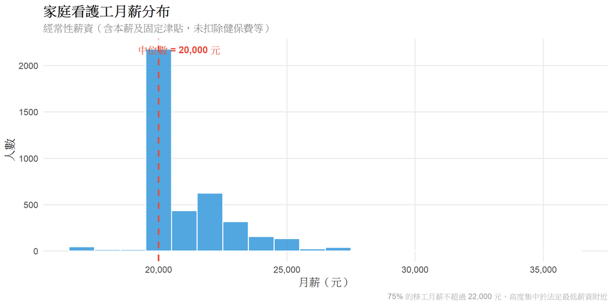

```r
median_w <- median(df$月薪, na.rm = TRUE)
mean_w   <- weighted.mean(df$月薪, df$權重, na.rm = TRUE)

df %>%
  filter(!is.na(月薪), 月薪 > 0, 月薪 < 40000) %>%
  ggplot(aes(x = 月薪)) +
  geom_histogram(binwidth = 1000, fill = "#3498DB", color = "white", alpha = 0.85) +
  geom_vline(xintercept = median_w, color = "#E74C3C", linewidth = 1, linetype = "dashed") +
  annotate("text", x = median_w + 800, y = Inf, vjust = 2,
           label = paste0("中位數 = ", comma(median_w), " 元"),
           color = "#E74C3C", fontface = "bold", size = 4) +
  scale_x_continuous(labels = comma) +
  labs(title = "家庭看護工月薪分布",
       subtitle = "經常性薪資（含本薪及固定津貼，未扣除健保費等）",
       caption = "75% 的移工月薪不超過 22,000 元，高度集中於法定最低薪資附近",
       x = "月薪（元）", y = "人數")
```

> **觀察**：月薪分布**高度右偏且集中**——中位數僅 20,000 元， 四分之三的移工月薪不超過 22,000 元。這意味著絕大多數雇主 以接近法定下限的金額支付薪資，薪資幾乎沒有議價空間。

## 1.2 有護理訓練 ≠ 較高薪資

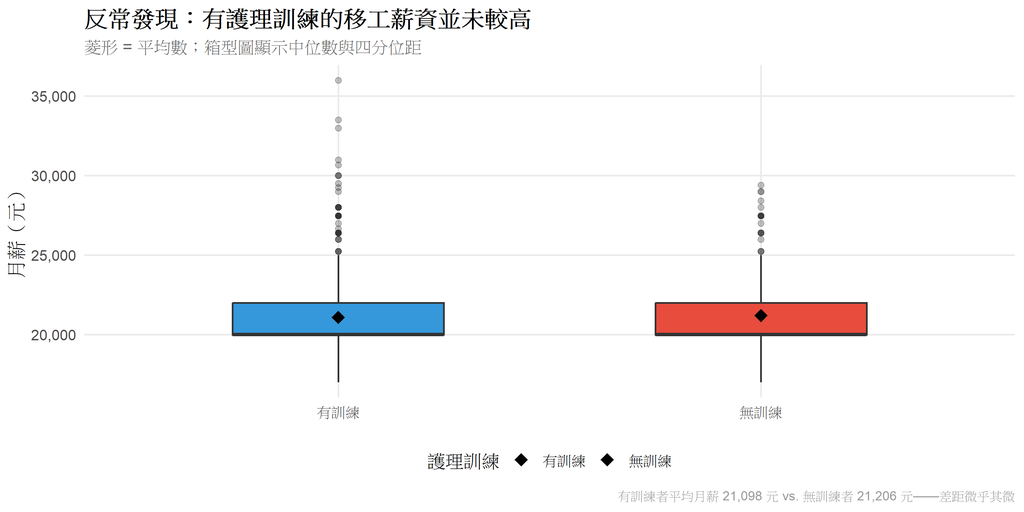

```r
df %>%
  filter(!is.na(月薪), !is.na(護理訓練), 月薪 > 0, 月薪 < 40000) %>%
  ggplot(aes(x = 護理訓練, y = 月薪, fill = 護理訓練)) +
  geom_boxplot(width = 0.5, outlier.alpha = 0.3, show.legend = FALSE) +
  stat_summary(fun = mean, geom = "point", shape = 18, size = 4, color = "black") +
  scale_fill_manual(values = pal2) +
  scale_y_continuous(labels = comma) +
  labs(title = "反常發現：有護理訓練的移工薪資並未較高",
       subtitle = "菱形 = 平均數；箱型圖顯示中位數與四分位距",
       caption = "有訓練者平均月薪 21,098 元 vs. 無訓練者 21,206 元——差距微乎其微",
       x = NULL, y = "月薪（元）")
```

> **反常**：受過護理訓練的移工與未受訓者薪資幾乎相同。 訓練帶來的「技能溢價」在家庭看護工市場中並未被反映在薪資上， 可能因為薪資多依法定基準給付，而非依技能差異定價。

## 1.3 年終獎金分布（滿一年者）

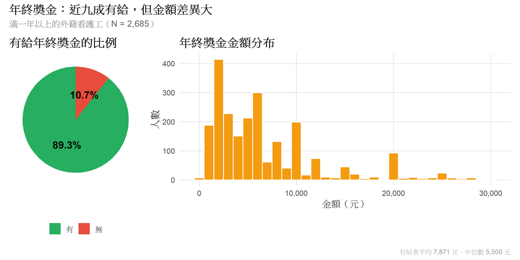

```r
df %>%
  filter(滿一年 == "已滿一年", !is.na(年終獎金)) %>%
  mutate(有獎金 = ifelse(年終獎金 > 0, "有", "無")) %>%
  count(有獎金, wt = 權重) %>%
  mutate(pct = n / sum(n)) -> bonus_summary

p1 <- bonus_summary %>%
  ggplot(aes(x = "", y = pct, fill = 有獎金)) +
  geom_col(width = 1) +
  coord_polar("y") +
  scale_fill_manual(values = pal_yesno) +
  geom_text(aes(label = percent(pct, accuracy = 0.1)),
            position = position_stack(vjust = 0.5), size = 5, fontface = "bold") +
  labs(title = "有給年終獎金的比例", x = NULL, y = NULL) +
  theme(axis.text = element_blank(), panel.grid = element_blank(),
        legend.title = element_blank())

p2 <- df %>%
  filter(滿一年 == "已滿一年", !is.na(年終獎金), 年終獎金 > 0,
         年終獎金 < 30000) %>%
  ggplot(aes(x = 年終獎金)) +
  geom_histogram(binwidth = 1000, fill = "#F39C12", color = "white") +
  scale_x_continuous(labels = comma) +
  labs(title = "年終獎金金額分布", x = "金額（元）", y = "人數")

p1 + p2 +
  plot_annotation(
    title = "年終獎金：近九成有給，但金額差異大",
    subtitle = "滿一年以上的外籍看護工（N = 2,685）",
    caption = "有給者平均 7,871 元、中位數 5,500 元"
  )
```